# Practical Machine Learning-Final Assignment

Morteza

July 2, 2017

## Business Problem

One thing that people regularly do is quantify how much of a particular activity they do, but they rarely quantify how well they do it. In this project, your goal will be to use data from accelerometers on the belt, forearm, arm, and dumbell of 6 participants to predict the manner in which they did the exercise.

## Understanding Data

The training data for this project are available here:

https://d396qusza40orc.cloudfront.net/predmachlearn/pml-training.csv

The test data are available here:

https://d396qusza40orc.cloudfront.net/predmachlearn/pml-testing.csv

The data for this project comes from http://groupware.les.inf.puc-rio.br/har. Full source:

Velloso, E.; Bulling, A.; Gellersen, H.; Ugulino, W.; Fuks, H. “Qualitative Activity Recognition of Weight Lifting Exercises. Proceedings of 4th International Conference in Cooperation with SIGCHI (Augmented Human ’13)”. Stuttgart, Germany: ACM SIGCHI, 2013.

Data description (from the authors’ website):

“Six young health participants were asked to perform one set of 10 repetitions of the Unilateral Dumbbell Biceps Curl in five different fashions: exactly according to the specification (Class A), throwing the elbows to the front (Class B), lifting the dumbbell only halfway (Class C), lowering the dumbbell only halfway (Class D) and throwing the hips to the front (Class E).

Class A corresponds to the specified execution of the exercise, while the other 4 classes correspond to common mistakes. Participants were supervised by an experienced weight lifter to make sure the execution complied to the manner they were supposed to simulate. The exercises were performed by six male participants aged between 20-28 years, with little weight lifting experience. We made sure that all participants could easily simulate the mistakes in a safe and controlled manner by using a relatively light dumbbell (1.25kg)."

```r
Train_url <- "http://d396qusza40orc.cloudfront.net/predmachlearn/pml-training.csv"
Test_url  <- "http://d396qusza40orc.cloudfront.net/predmachlearn/pml-testing.csv"

training <- read.csv(url(Train_url))
testing  <- read.csv(url(Test_url))

dim(training)
```

```
## [1] 19622   160
```

```r
dim(testing)
```

```
## [1]  20 160
```

## Preparing Data

```r
# remove variables with Zero variance and those variables with more than 95% NA data

NZV <- nearZeroVar(training)
training <- training[, -NZV]
dim(training)
```

```
## [1] 19622   100
```

```r
Data_NA    <- sapply(training, function(x) mean(is.na(x))) > 0.95
training <- training[, Data_NA==FALSE]
dim(training)
```

```
## [1] 19622    59
```

```r
# remove identification only variables (columns 1 to 5)
training <- training[, -(1:7)]

# create a partition with the training dataset
inTrain  <- createDataPartition(training$classe, p=0.7, list=FALSE)
TrainSet <- training[inTrain, ]
TestSet  <- training[-inTrain, ]
```

## Developing Predictive Model

```r
# model fit
set.seed(12345)
controlRF <- trainControl(method="cv", number=3, verboseIter=FALSE)
modFit <- train(classe ~ ., data=TrainSet, method="rf",
                          trControl=controlRF)
modFit$finalModel
```

```
##
## Call:
##  randomForest(x = x, y = y, mtry = param$mtry)
##                Type of random forest: classification
##                      Number of trees: 500
## No. of variables tried at each split: 2
##
##         OOB estimate of  error rate: 0.74%
## Confusion matrix:
##      A    B    C    D    E class.error
## A 3902    1    2    0    1 0.001024066
## B   15 2633   10    0    0 0.009405568
## C    0   22 2372    2    0 0.010016694
## D    0    0   40 2210    2 0.018650089
## E    0    0    1    5 2519 0.002376238
```

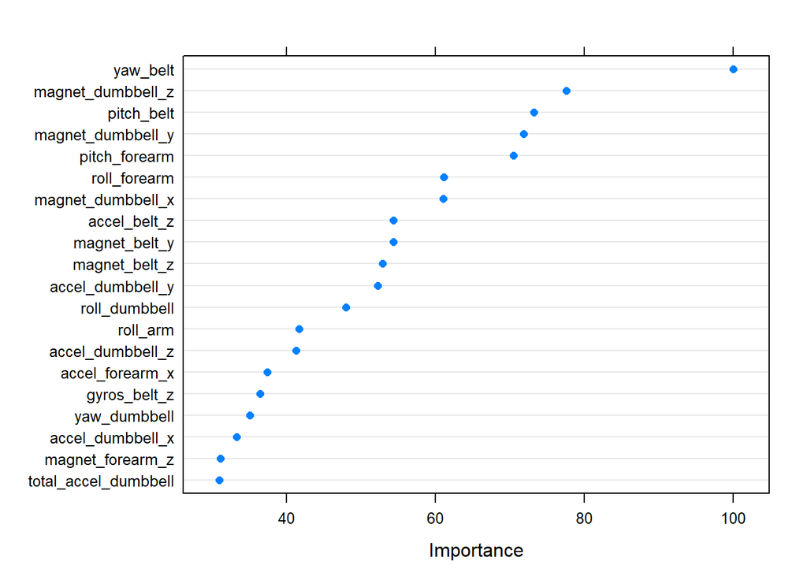

```r
Varimportance <- varImp(modFit, scale=TRUE)
dotPlot(Varimportance, top = min(20, dim(Varimportance$importance)[1]))
```

```r
# prediction on Test dataset
predict <- predict(modFit, newdata=TestSet)
confMat <- confusionMatrix(predict, TestSet$classe)
confMat
```

```
## Confusion Matrix and Statistics
##
##           Reference
## Prediction    A    B    C    D    E
##          A 1672   11    0    0    0
##          B    2 1122   17    0    0
##          C    0    6 1005   27    0
##          D    0    0    4  937    3
##          E    0    0    0    0 1079
##
## Overall Statistics
##
##                Accuracy : 0.9881
##                  95% CI : (0.985, 0.9907)
##     No Information Rate : 0.2845
##     P-Value [Acc > NIR] : < 2.2e-16
##
##                   Kappa : 0.985
##  Mcnemar's Test P-Value : NA
##
## Statistics by Class:
##
##                      Class: A Class: B Class: C Class: D Class: E
## Sensitivity            0.9988   0.9851   0.9795   0.9720   0.9972
## Specificity            0.9974   0.9960   0.9932   0.9986   1.0000
## Pos Pred Value         0.9935   0.9833   0.9682   0.9926   1.0000
## Neg Pred Value         0.9995   0.9964   0.9957   0.9945   0.9994
## Prevalence             0.2845   0.1935   0.1743   0.1638   0.1839
## Detection Rate         0.2841   0.1907   0.1708   0.1592   0.1833
## Detection Prevalence   0.2860   0.1939   0.1764   0.1604   0.1833
## Balanced Accuracy      0.9981   0.9905   0.9864   0.9853   0.9986
```

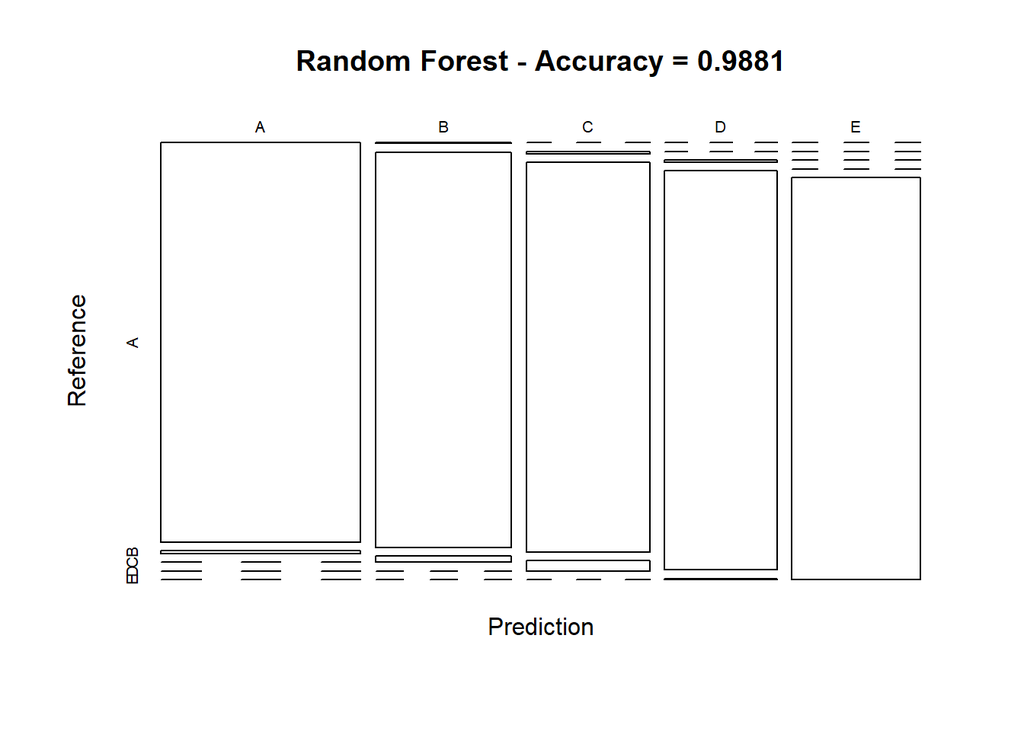

```r
# plot matrix results
plot(confMat$table, col = confMat$byClass,
     main = paste("Random Forest - Accuracy =",
                  round(confMat$overall['Accuracy'], 4)))
```

## Applying the selected model to the test data set

```r
predictTEST <- predict(modFit, newdata=testing)
predictTEST
```

```
##  [1] B A B A A E D B A A B C B A E E A B B B
## Levels: A B C D E
```